# Covid ActNow Data API

Adriel E. Lorenzo

2024-06-09

## 0.1 Estrucutura del documento CSV

Este documento proporciona un seguimiento del COVID-19 en los Estados Unidos utilizando datos de la API de Covid ActNow. Se analizará la población por estado y la tasa de contagios, presentando los resultados en gráficos que permiten una visualización clara y concisa de la situación actual.

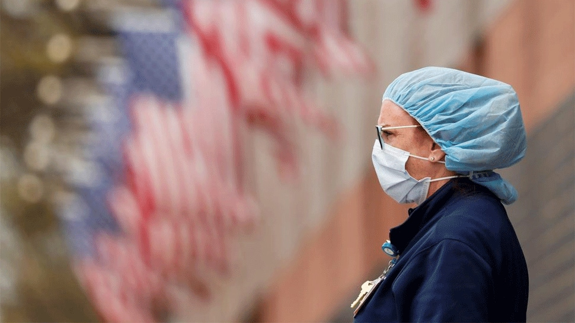

### 0.1.1 Resumen documento CSV generado de la API Covid ActNow

Los datos se obtuvieron de la API de Covid ActNow y se procesaron para obtener información relevante sobre la población y la tasa de contagios por estado.

```
##     State             Population           Cases          InfectionRate
##  Length:50          Min.   :  578759   Min.   :  154243   Min.   :22816
##  Class :character   1st Qu.: 1827712   1st Qu.:  593990   1st Qu.:29173
##  Mode  :character   Median : 4558234   Median : 1489998   Median :32147
##                     Mean   : 6550675   Mean   : 2065278   Mean   :31715
##                     3rd Qu.: 7530849   3rd Qu.: 2433327   3rd Qu.:34265
##                     Max.   :39512223   Max.   :12251820   Max.   :41673
```

### 0.1.2 Contenido del documento CSV

Como se puede apreciar esta es la tabla del archivo CSV en ella exporte los datos mas importantes a mi parecer que son los estados, en ellos igual esta la población de cada uno de ellos y de igual manera los casos de infección que se presentan en ellos.

| State | Population | Cases | InfectionRate |
| --- | --- | --- | --- |
| Alaska | 731545 | 297588 | 40679.38 |
| Alabama | 4903185 | 1659936 | 33854.24 |
| Arkansas | 3017804 | 995043 | 32972.42 |
| Arizona | 7278717 | 2474154 | 33991.62 |
| California | 39512223 | 12251820 | 31007.67 |
| Colorado | 5758736 | 1783663 | 30973.17 |
| Connecticut | 3565287 | 982335 | 27552.76 |
| Delaware | 973764 | 333772 | 34276.48 |
| Florida | 21477737 | 7572282 | 35256.42 |
| Georgia | 10617423 | 3087729 | 29081.72 |

[output cut: 40 more lines]

### 0.1.3 Campos de archivos CSV

Los campos del CSV son los siguientes como dije representan uno de los datos mas importantes para realizar el análisis.

[figure not shown]

```
## [1] "State"         "Population"    "Cases"         "InfectionRate"
```

#### 0.1.3.1 Numero de registros

```
## [1] 50
```

## 0.2 Grafica de Tasa de contagios por estado en Estados unidos

A continuación se presenta un análisis de la población por estado en Estados Unidos.

### 0.2.1 Gráfico de Población por Estado

Como se puede observar en el gráfico, la distribución de la población varía significativamente entre los estados. Los estados más poblados son California, Texas y Florida, mientras que los estados menos poblados incluyen Wyoming, Vermont y Alaska.

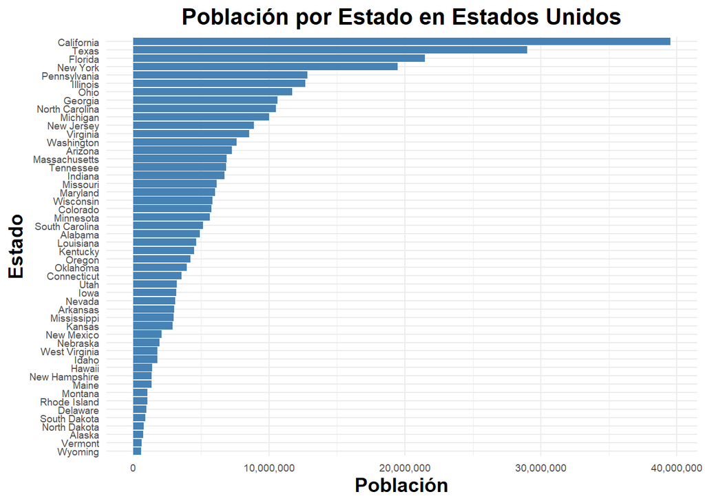

### 0.2.2 Gráfico de Tasa de Contagios por Estado

El gráfico muestra la tasa de contagios por cada 100,000 habitantes en cada estado. Se puede ver que hay una variabilidad considerable en la tasa de contagios entre los estados.

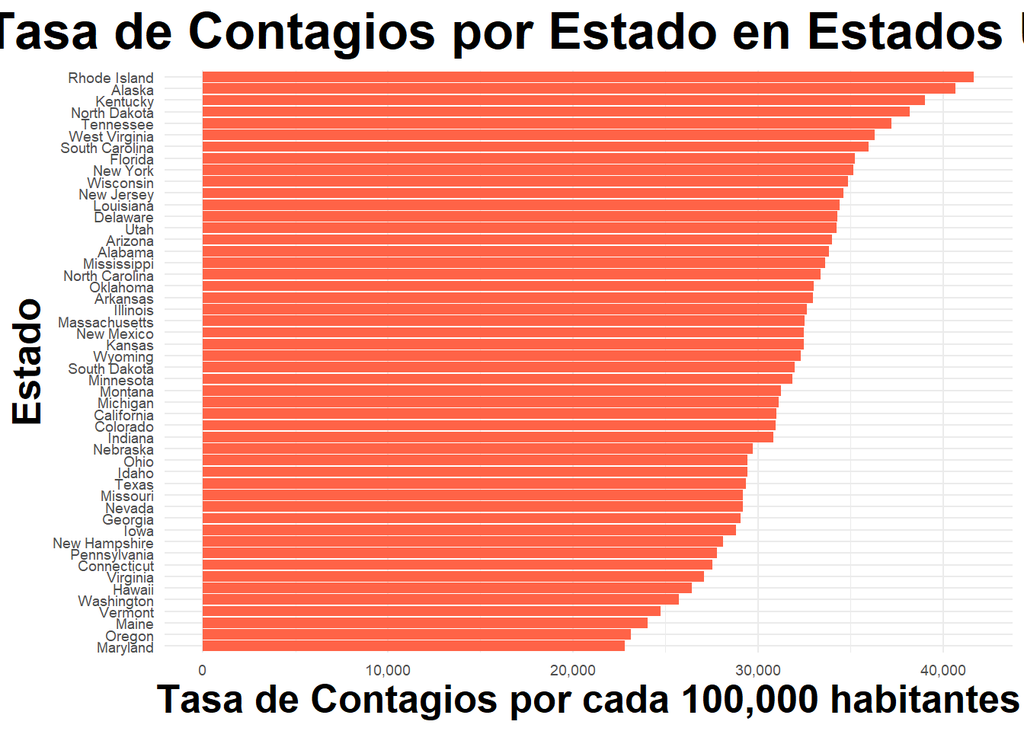

## 0.3 Conclusiones

En este análisis, se ha presentado un seguimiento del COVID-19 en los Estados Unidos utilizando datos de la API de Covid ActNow. Hemos visualizado la población por estado y la tasa de contagios, lo que nos permite entender mejor la distribución y el impacto de la pandemia en diferentes regiones del país.

Algunos hallazgos clave incluyen:

- La población está desigualmente distribuida entre los estados, con California, Texas y Florida siendo los más poblados.
- La tasa de contagios varía significativamente entre los estados, lo que puede reflejar diferencias en la gestión de la pandemia, la densidad de población y otros factores.

Este análisis proporciona una base para futuras investigaciones y decisiones informadas sobre la gestión de la pandemia en Estados Unidos.

[figure not shown]